# Partial Least Squares Regression (PLSR) for Quantifying Coffee Adulteration: Spectral Preprocessing Using SNV, Savitzky-Golay, and First Derivative

Author

Derick Malavi

## Introduction

Coffee adulteration, such as blending premium Arabica with lower-cost Robusta, undermines quality and authenticity, posing significant challenges for consumers, producers, and regulators. High-dimensional spectroscopic data, encompassing the full spectrum, provides valuable insights for detecting such fraud. However, the large number of variables requires advanced techniques to effectively model the data without overfitting.

```r
# Load libraries
warning = FALSE
  suppressWarnings(suppressMessages({
  library(caret)
  library(GA)
  library(viridis)
  library(Boruta)
  library(ggplot2)
  library(dplyr)
  library(readxl)
  library(readr)
  library(pls)
  library(janitor)
  library(class)
  library(MLmetrics)
  library(MLeval)
  library(themis)
  library(ROSE)
  library(parallel)
  library(doParallel)
  library(foreach)
  library(pheatmap)
  library(mdatools)
  library(nnet)
  library(DMwR)
  library(e1071)
  library(knitr)
  library(pROC)
  library(gridExtra)
  library(FactoMineR)
  library(doSNOW)
  library(MASS)
  library(factoextra)
  library(kernlab)}))
```

## Prepare Data

```r
# Load data: snv_sg_1d spectra

hsi_snv_sg_1d <- read.csv("coffee_ground_snv_sg_1d.csv")

# Ensure we have the same number of dimensions and the range of our columns/covariates
dim(hsi_snv_sg_1d)
```

```
[1] 1469  229
```

```r
# Check a few column names
col_check <- colnames(hsi_snv_sg_1d[,c(1:6)])
col_check
```

```
[1] "sample_id"     "binary_class"  "three_class"   "adult_percent"
[5] "cal_val"       "X935.609985"
```

```r
# our response variable (adulteration percentage) is column 4
# The spectral values start from column # 6 -------> 229

# Convert the adulteration percentage to numeric for compatibility with ML
hsi_snv_sg_1d$adult_percent <- as.numeric(hsi_snv_sg_1d$adult_percent)
```

## Get the X and y variables

```r
X <- hsi_snv_sg_1d[,c(6:229)]
y <- hsi_snv_sg_1d[,4]

class(y) #Ensure y (target variable) is a numeric for regression
```

```
[1] "numeric"
```

## Visualize X

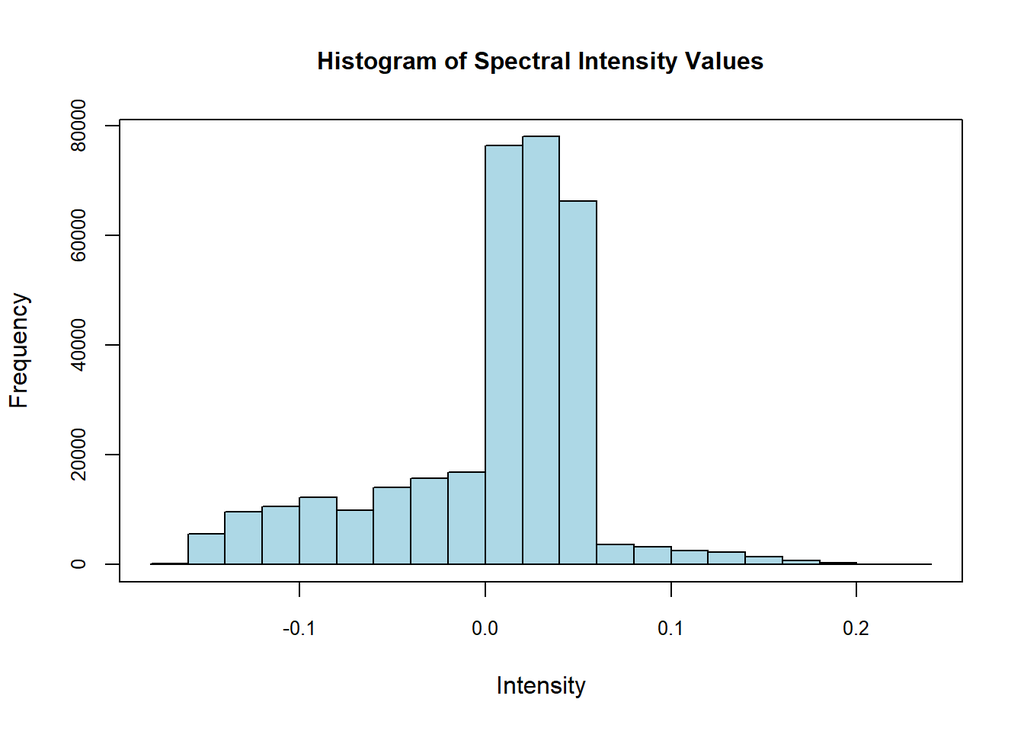

```r
hist(as.matrix(X), col = 'lightblue', cex.main = 1.0, cex.axis = 0.8,cex.lab = 1.0,
     main = 'Histogram of Spectral Intensity Values', xlab = 'Intensity'); box()
```

## Split the Data (Train_Test Split)

- We want to select features based on training data only to avoid any data leakage that could inflate model performance and make the model less generalizable to unseen data.

```r
# Subset samples for cross-validation and external validation (70/30)
# Record 1 under cal_val variable is for calibration while 2 will be for testing the model

sample<-hsi_snv_sg_1d$cal_val == 1

# Split to train and test sets
X_train <- X[sample,]
X_test <- X[!sample,]
y_train <-y[sample]
y_test <- y[!sample]

# Check length of the subsets for training and validation
dim(X_train)
```

```
[1] 1055  224
```

```r
dim(X_test)
```

```
[1] 414 224
```

```r
length(y_train)
```

```
[1] 1055
```

```r
length(y_test)
```

```
[1] 414
```

```r
# Merge the test and train data
train_data <- data.frame(y_train, X_train)
test_data <- data.frame(y_test, X_test)
```

## Check correlations by HeatMaps

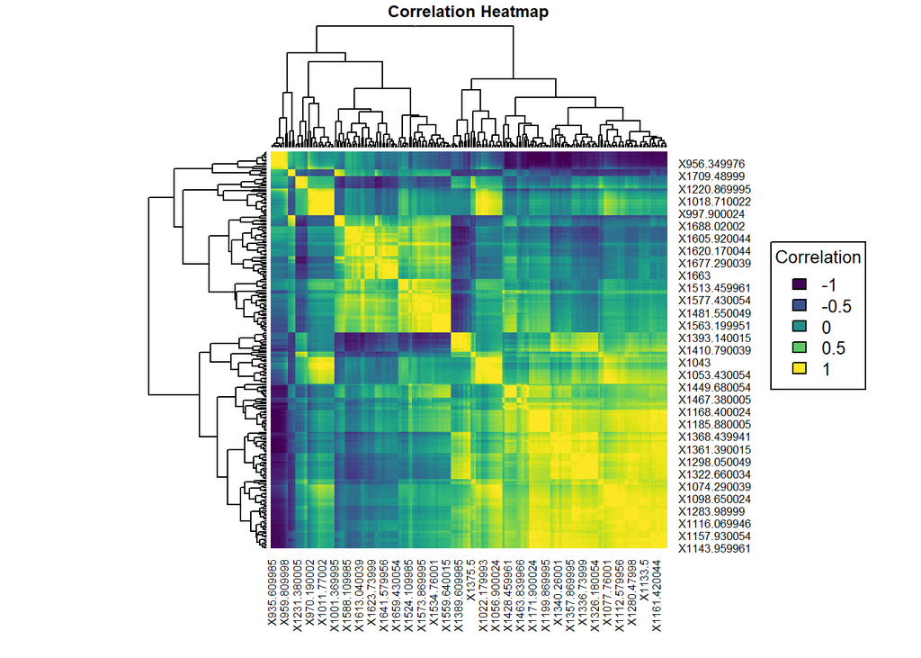

```r
#Calculate correlations
corr <- cor(train_data[,-1])

# Create a heat map
par(cex.main = 0.6)
heatmap(corr, symm = TRUE,
        col = viridis(50),
        main = "Correlation Heatmap")

# Add legend
legend("right",
       legend = seq(-1, 1, by = 0.5),  # Correlation range
       fill = viridis(5),
       title = "Correlation", cex = 0.8)
```

## Train Models

- We will train models based all spectral features

```r
# Set random seed for reproducibility
set.seed (123)

# Set up the training control(10 folds 10 times cross_validation)
control <- trainControl(method = "repeatedcv", number = 10, repeats = 10,
                        savePredictions = "final",
                        summaryFunction = defaultSummary,
                        selectionFunction = 'best', allowParallel = TRUE)

# We used oneSE for classification. For regression, we will use 'best': a model that minimizes RMSECV
```

```r
#Set the metric as accuracy
metric<-"RMSE"
```

```r
# Hyperparameter Tuning
# We will use tune Length to automatically determine the optimal number of PLS components
```

```r
set.seed(123)
#Register cluster for caret to train the models in parallel
cl<-makeCluster(6,type = "SOCK")
suppressWarnings(suppressMessages(
  registerDoSNOW(cl)))

# Start_time
start_time<-Sys.time()

#Train the model using cross-validation (10 folds, 10 times)
fit_pls_snv_sg_1d<-train(y = train_data[,1],
                         x = train_data[,-1],
                         method = 'pls', tuneLength = 50,
                         trControl = control,
                         metric = metric)
#End_time
end_time<-Sys.time()

model_training_time<-end_time-start_time

stopCluster(cl) # Stop the parallel run cluster

print(model_training_time)
```

```
Time difference of 14.58211 secs
```

```r
# Display regression results
print(fit_pls_snv_sg_1d)
```

```
Partial Least Squares

1055 samples
 224 predictor

No pre-processing
Resampling: Cross-Validated (10 fold, repeated 10 times)
Summary of sample sizes: 949, 949, 949, 948, 949, 950, ...
Resampling results across tuning parameters:

  ncomp  RMSE       Rsquared   MAE
   1     20.961286  0.4702258  16.468668
   2     17.025976  0.6508141  13.381611
   3     12.085493  0.8249211   9.539823
   4     11.715642  0.8355475   9.302279
```

[output cut: 49 more lines]

## Save the models for future use

```r
saveRDS(fit_pls_snv_sg_1d, "fit_pls_snv_sg_1d.rds")
```

## Plot the cross-validation results —–> Model Selection

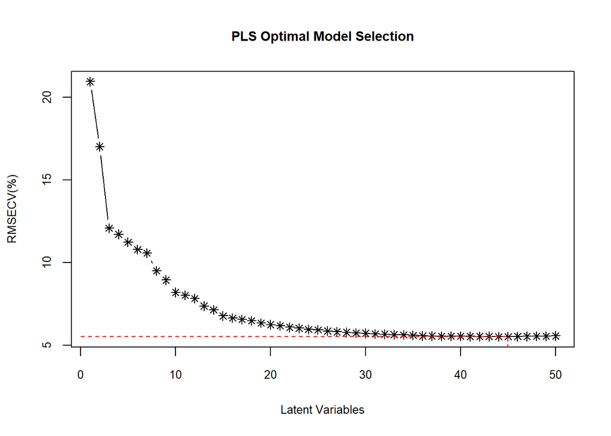

```r
# Imbalanced Data
pls_data <- fit_pls_snv_sg_1d$results
best_Lvs = fit_pls_snv_sg_1d$bestTune$ncomp
y_RMSE = pls_data$RMSE[pls_data$ncomp == best_Lvs]
plot(pls_data$ncomp,pls_data$RMSE, type = "b",col = "black",pch = 8,cex.axis = 0.8,
     xlab = "Latent Variables", ylab = "RMSECV(%)",cex.lab = 0.9,
     main = 'PLS Optimal Model Selection',
     cex.main = 0.9,
     cex.lab = 0.8)
# Add line from x-axis to the specific point
segments(x0 = best_Lvs, y0 = 0, x1 = best_Lvs, y1 = y_RMSE, col = "red", lty = 2)

# Add line from y-axis to the specific point
segments(x0 = 0, y0 = y_RMSE, x1 = best_Lvs, y1 = y_RMSE, col = "red", lty = 2)
```

## Display the cross-validation results

```r
print(paste('The optimal parameters for training the pls model is',
            fit_pls_snv_sg_1d$bestTune$ncomp, 'components'))
```

```
[1] "The optimal parameters for training the pls model is 45 components"
```

## Display CV Results in Tables

```r
kable(fit_pls_snv_sg_1d$results)
```

| ncomp | RMSE | Rsquared | MAE | RMSESD | RsquaredSD | MAESD |
| --- | --- | --- | --- | --- | --- | --- |
| 1 | 20.961286 | 0.4702258 | 16.468668 | 1.1677058 | 0.0586531 | 1.0939144 |
| 2 | 17.025976 | 0.6508141 | 13.381611 | 1.3562095 | 0.0517943 | 0.8207094 |
| 3 | 12.085494 | 0.8249211 | 9.539824 | 0.8433889 | 0.0226889 | 0.6183680 |
| 4 | 11.715642 | 0.8355475 | 9.302279 | 0.7773577 | 0.0205399 | 0.6227136 |
| 5 | 11.238793 | 0.8485187 | 8.780989 | 0.8229349 | 0.0210184 | 0.6620536 |
| 6 | 10.801827 | 0.8599575 | 8.447853 | 0.9553818 | 0.0229481 | 0.6330537 |
| 7 | 10.569003 | 0.8660679 | 8.266406 | 0.8820689 | 0.0211200 | 0.6063774 |
| 8 | 9.506251 | 0.8922403 | 7.572942 | 0.6481997 | 0.0133473 | 0.5054258 |
| 9 | 8.945633 | 0.9048126 | 7.121552 | 0.6265775 | 0.0121545 | 0.4986046 |
| 10 | 8.197994 | 0.9201977 | 6.540273 | 0.5957472 | 0.0104669 | 0.4824074 |
| 11 | 8.022519 | 0.9234938 | 6.388570 | 0.5632287 | 0.0097518 | 0.4735037 |
| 12 | 7.819551 | 0.9272289 | 6.243284 | 0.5393124 | 0.0090710 | 0.4612287 |
| 13 | 7.371869 | 0.9353374 | 5.837622 | 0.5155336 | 0.0082747 | 0.4202242 |
| 14 | 7.133149 | 0.9394409 | 5.748632 | 0.5007323 | 0.0078150 | 0.4153942 |
| 15 | 6.772574 | 0.9454401 | 5.382750 | 0.4921138 | 0.0071400 | 0.3938962 |
| 16 | 6.643108 | 0.9475305 | 5.268975 | 0.4890632 | 0.0071966 | 0.3867786 |
| 17 | 6.554820 | 0.9489626 | 5.212002 | 0.4487042 | 0.0063722 | 0.3549740 |
| 18 | 6.475921 | 0.9501923 | 5.106648 | 0.4264013 | 0.0059318 | 0.3397306 |
| 19 | 6.343579 | 0.9521636 | 5.003435 | 0.3974896 | 0.0057035 | 0.3306406 |
| 20 | 6.241825 | 0.9536429 | 4.911386 | 0.4255248 | 0.0060276 | 0.3441287 |
| 21 | 6.182906 | 0.9545108 | 4.872318 | 0.4235253 | 0.0060045 | 0.3382982 |
| 22 | 6.081005 | 0.9560226 | 4.791842 | 0.4276827 | 0.0059492 | 0.3600887 |
| 23 | 6.027228 | 0.9568203 | 4.757851 | 0.4260507 | 0.0059417 | 0.3550866 |
| 24 | 5.964526 | 0.9577570 | 4.712216 | 0.3965000 | 0.0055598 | 0.3349877 |
| 25 | 5.933481 | 0.9581873 | 4.657903 | 0.3856317 | 0.0054693 | 0.3289422 |
| 26 | 5.858463 | 0.9592459 | 4.621791 | 0.3987397 | 0.0054912 | 0.3257566 |
| 27 | 5.810515 | 0.9599357 | 4.611104 | 0.3951301 | 0.0054535 | 0.3329568 |
| 28 | 5.773551 | 0.9604393 | 4.591199 | 0.3664265 | 0.0050779 | 0.3127927 |
| 29 | 5.740449 | 0.9609170 | 4.553351 | 0.3610653 | 0.0049026 | 0.3019175 |
| 30 | 5.721896 | 0.9611592 | 4.517384 | 0.3686191 | 0.0049401 | 0.3009717 |
| 31 | 5.689406 | 0.9616261 | 4.507123 | 0.3576365 | 0.0047735 | 0.2987024 |
| 32 | 5.663953 | 0.9619658 | 4.493662 | 0.3676302 | 0.0049223 | 0.3070905 |
| 33 | 5.640135 | 0.9622861 | 4.458489 | 0.3687795 | 0.0049352 | 0.3050333 |
| 34 | 5.629923 | 0.9624340 | 4.458086 | 0.3617690 | 0.0048565 | 0.2909996 |
| 35 | 5.597526 | 0.9628989 | 4.436775 | 0.3592042 | 0.0047424 | 0.2953680 |
| 36 | 5.563010 | 0.9633329 | 4.415714 | 0.3642747 | 0.0047365 | 0.2904854 |
| 37 | 5.555884 | 0.9634387 | 4.423366 | 0.3510864 | 0.0045420 | 0.2808215 |
| 38 | 5.551103 | 0.9634998 | 4.430915 | 0.3478956 | 0.0045197 | 0.2785290 |
| 39 | 5.545949 | 0.9635779 | 4.424591 | 0.3409227 | 0.0044573 | 0.2743618 |
| 40 | 5.548089 | 0.9635547 | 4.428973 | 0.3454385 | 0.0044882 | 0.2833961 |
| 41 | 5.533426 | 0.9637694 | 4.413982 | 0.3476649 | 0.0045068 | 0.2871001 |
| 42 | 5.528965 | 0.9638221 | 4.413843 | 0.3418448 | 0.0044251 | 0.2842802 |
| 43 | 5.527350 | 0.9638443 | 4.407024 | 0.3416821 | 0.0044574 | 0.2780975 |
| 44 | 5.518819 | 0.9639626 | 4.405793 | 0.3367007 | 0.0043756 | 0.2763341 |
| 45 | 5.511670 | 0.9640464 | 4.410783 | 0.3366195 | 0.0043853 | 0.2730040 |
| 46 | 5.525463 | 0.9638664 | 4.418850 | 0.3304921 | 0.0043500 | 0.2694526 |
| 47 | 5.531524 | 0.9637826 | 4.419017 | 0.3282049 | 0.0043425 | 0.2709614 |
| 48 | 5.544075 | 0.9636266 | 4.430161 | 0.3264520 | 0.0043213 | 0.2676172 |
| 49 | 5.550490 | 0.9635550 | 4.439379 | 0.3255089 | 0.0042993 | 0.2627244 |
| 50 | 5.560490 | 0.9634348 | 4.450323 | 0.3202138 | 0.0042512 | 0.2605167 |

```r
# Select row for the optimal model
opt_row <- fit_pls_snv_sg_1d$results %>%
  filter(ncomp==fit_pls_snv_sg_1d$bestTune$ncomp)

kable(opt_row)
```

| ncomp | RMSE | Rsquared | MAE | RMSESD | RsquaredSD | MAESD |
| --- | --- | --- | --- | --- | --- | --- |
| 45 | 5.51167 | 0.9640464 | 4.410783 | 0.3366195 | 0.0043853 | 0.273004 |

## Test the model performance on test data

```r
#Predict on the test set
observed <- test_data$y_test
predictions <- predict(fit_pls_snv_sg_1d,newdata=test_data)

# Generate predictions
results <- postResample(predictions, observed)

print(results)
```

```
     RMSE  Rsquared       MAE
8.8566388 0.9167046 7.2017007
```

```r
RMSEP = results[[1]]
R2 = results[[2]]
MAE = results[[3]]

cat('The RMSEP for the model on external validation is:', RMSEP,'\n')
```

```
The RMSEP for the model on external validation is: 8.856639
```

```r
cat('The R Squared value for the model is:', R2,'\n')
```

```
The R Squared value for the model is: 0.9167046
```

```r
# Calculate Residual Predictive Deviation to check model performance

RPD = sd(observed)/RMSEP

print(paste('The RPD values for the model is', round(RPD,2)))
```

```
[1] "The RPD values for the model is 3.29"
```

## Visualizations

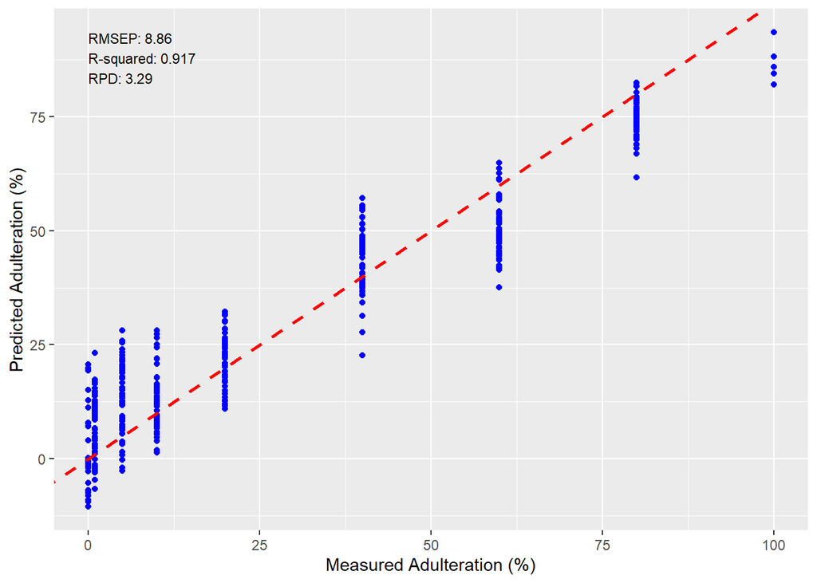

```r
# predicted vs observed line and scatter
# Create a data frame
results_df <- data.frame(observed=observed, predictions=predictions)

results_df %>%
  ggplot(aes(x = observed, y = predictions)) +
  geom_point(color = "blue") +
  geom_abline(slope = 1, intercept = 0, color = "red",
              linetype = "dashed", linewidth = 1) +
  labs( x = "Measured Adulteration (%)",
    y = "Predicted Adulteration (%)") +
  annotate("text",
    x = min(observed), y = max(predictions),
    label = paste("RMSEP:", round(RMSEP, 2),
      "\nR-squared:", round(R2, 3),
      "\nRPD:", round(RPD, 2)),
    hjust = 0, vjust = 1, size = 3, color = "black") +
  theme(
    axis.title = element_text(color = "black", size = 10),
    axis.text = element_text(color = "black"))+
  theme_gray()
```

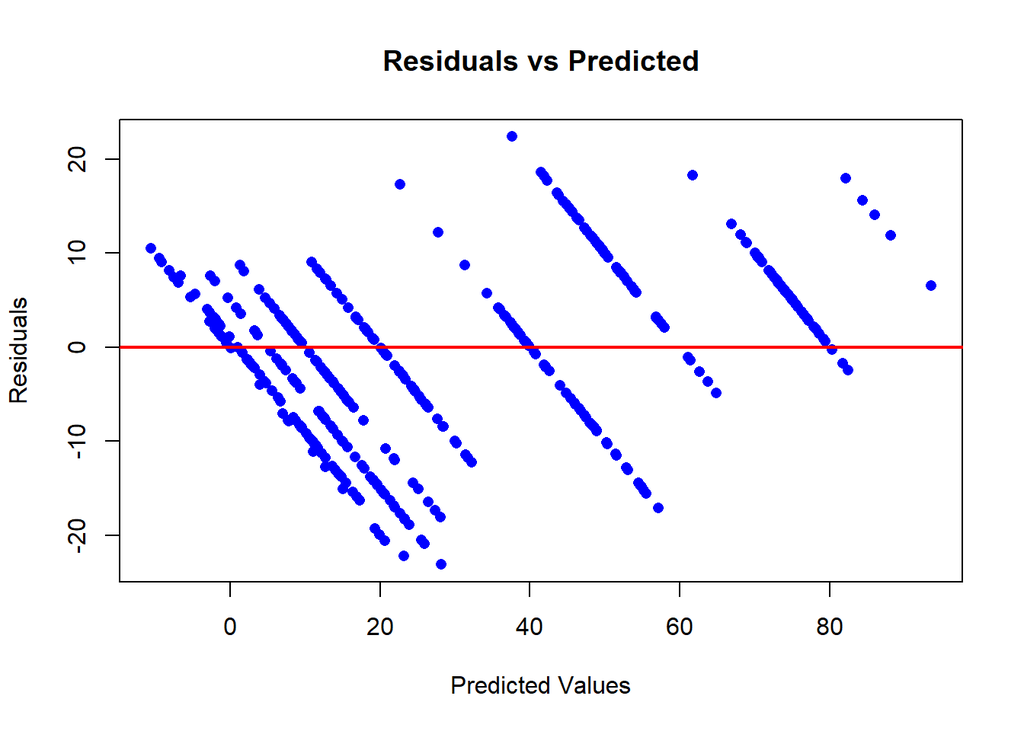

```r
# Check residuals

residuals <- observed - predictions

# Plot Residuals
plot(predictions, residuals,
     xlab = "Predicted Values",
     ylab = "Residuals",
     main = "Residuals vs Predicted",
     pch = 16, col = "blue")
abline(h = 0, col = "red", lwd = 2)
```

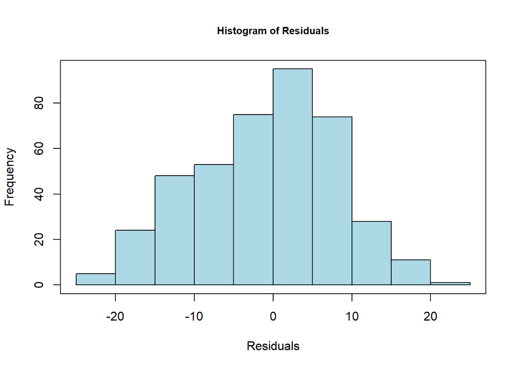

```r
hist(residuals,
     main = "Histogram of Residuals",
     xlab = "Residuals", cex.main = 0.8,
     col = "lightblue", border = "black"); box()
```